# Presentation

Casual deep learning

2023-06-13

# Description

Raisins can be of two species: *Kecimen* *(Class = 1)* and *Besni (Class = 0)*.  
We built different models to predict the species on the basis of the dimensions of the raisin example approximated as an ellipse.  
Data are taken from the paper: https://dergipark.org.tr/tr/download/article-file/1227592 and are available at: https://www.kaggle.com/datasets/muratkokludataset/raisin-dataset

## Variables

The predictors that can be used are:

- Area
- MajorAxisLength
- MinorAxisLength
- Eccentricity
- ConvexArea
- Extent
- Perimeter

The target variable is Class.

# Descriptive Analysis

#### Loading Libraries

```r
library(ggplot2)
library(dplyr)
library(tidyverse)
library(tidymodels)
library(glmnet)
library(estimatr)
library(stats)
library(maxLik)
library(Matrix)
library(caret)
library(performance)
library(see)
library(corrplot)
library(GGally)
library(car)
library(FactoMineR)
library(factoextra)
library(dplyr)
library(e1071)
library(caTools)
library(class)
library(pROC)
library(tree)
library(leaps)   # best subset
library(bestglm) # best subset for logistic
library(MASS)    # diagnostics
library(olsrr)   # diagnostics
library(influence.ME)
library(DHARMa) #logit diagnostics
```

#### Loading data-set

(Aim: visualize dataset, summary, remove Class_literal)

```r
raisins = read.csv(
  "https://raw.githubusercontent.com/LeonardoAcquaroli/raisins_and_mushrooms/main/datasets/Raisin_Dataset.csv",
  sep = ";"
)

head(raisins)
```

```
##    Area MajorAxisLength MinorAxisLength Eccentricity ConvexArea    Extent
## 1 87524        442.2460        253.2912    0.8197384      90546 0.7586506
## 2 75166        406.6907        243.0324    0.8018052      78789 0.6841296
## 3 90856        442.2670        266.3283    0.7983536      93717 0.6376128
## 4 45928        286.5406        208.7600    0.6849892      47336 0.6995994
## 5 79408        352.1908        290.8275    0.5640113      81463 0.7927719
## 6 49242        318.1254        200.1221    0.7773513      51368 0.6584564
##   Perimeter Class_literal Class
## 1  1184.040       Kecimen     1
## 2  1121.786       Kecimen     1
## 3  1208.575       Kecimen     1
## 4   844.162       Kecimen     1
## 5  1073.251       Kecimen     1
## 6   881.836       Kecimen     1
```

```r
# remove the Class_literal  column
raisins_corr <- raisins
raisins <- raisins[,-8]
# Class: 1 if raisin is of Kecimen type, 0 if it is Besni
```

### Correlations plots

(Aim: visually represent relationships between variables)

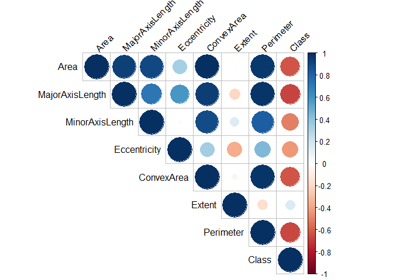

```r
cor_table<-cor(raisins)

corrplot(cor_table, type = "upper",     #first corr plot
         tl.col = "black", tl.srt = 45)
```

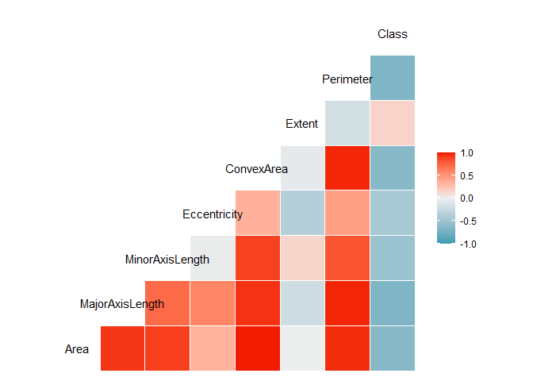

```r
ggcorr(raisins, method = c("everything", "pearson")) #heatmap plot
```

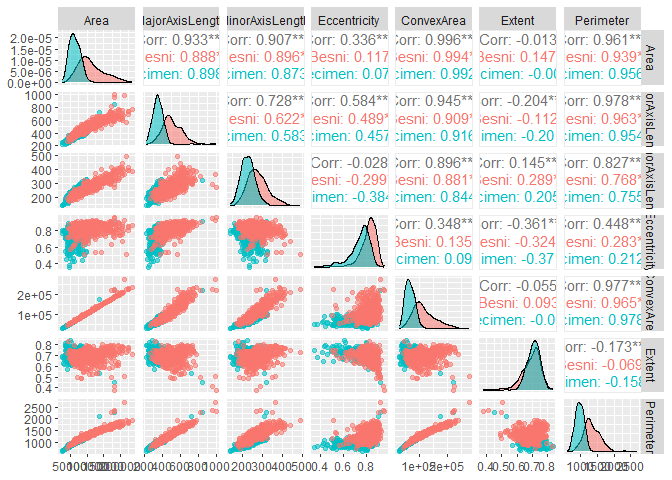

```r
ggpairs(raisins_corr, columns = 1:7, ggplot2::aes(colour= Class_literal, alpha = 0.005)) #cor by groups
```

### Boxplot

(Aim: Identify outliers)

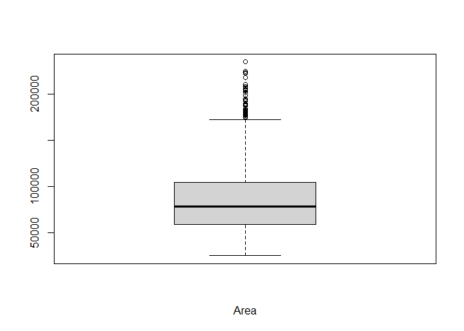

```r
boxplot(raisins$Area, xlab = "Area")
```

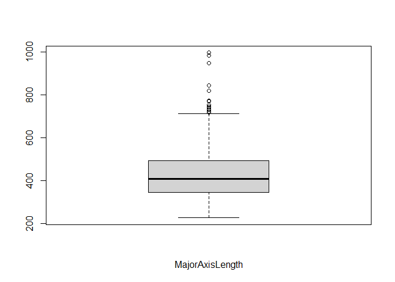

```r
boxplot(raisins$MajorAxisLength, xlab = "MajorAxisLength")
```

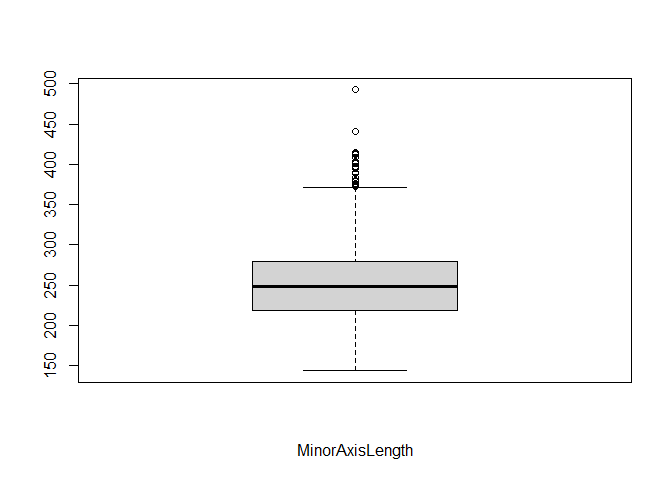

```r
boxplot(raisins$MinorAxisLength, xlab = "MinorAxisLength")
```

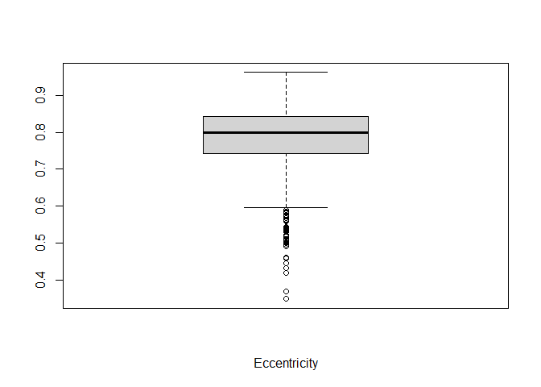

```r
boxplot(raisins$Eccentricity, xlab = "Eccentricity")
```

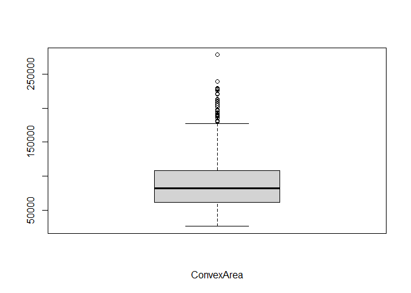

```r
boxplot(raisins$ConvexArea, xlab = "ConvexArea")
```

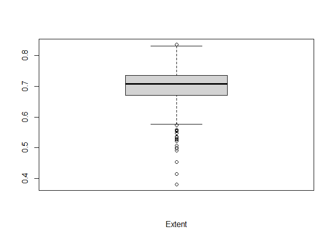

```r
boxplot(raisins$Extent, xlab = "Extent")
```

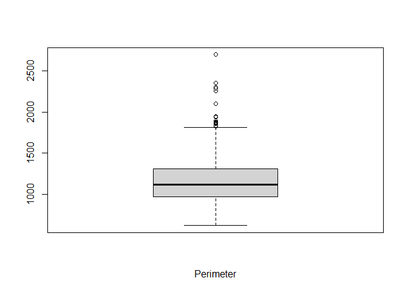

```r
boxplot(raisins$Perimeter, xlab = "Perimeter")
```

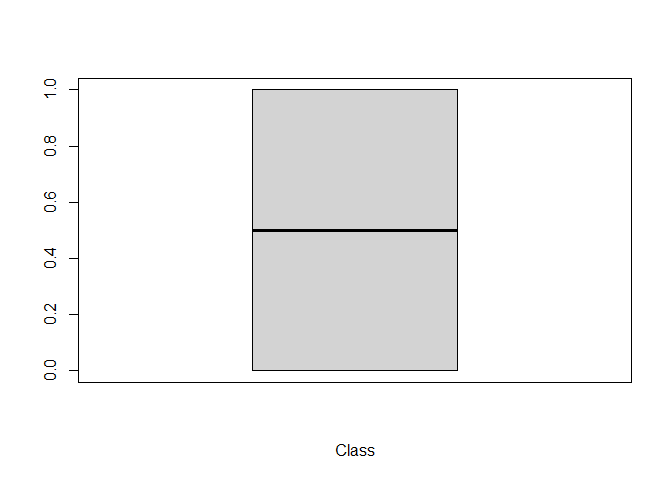

```r
boxplot(raisins$Class, xlab = "Class")
```

### Histograms highlighting class differences

(Aim: See more clearly if variables’ distribution depend on Class)

```r
library(ggthemes)
```

Black: Kecimen, Yellow: Besni

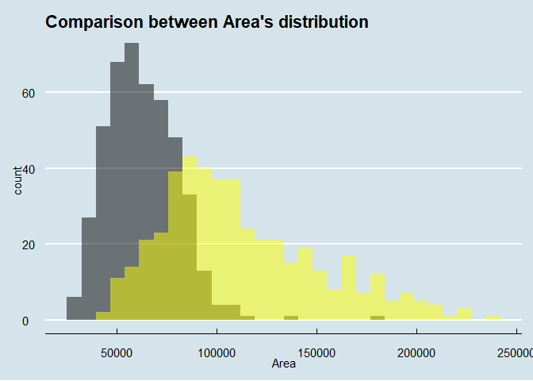

```r
theme_set(theme_economist())

ggplot() +
geom_histogram(data = subset(x=raisins, subset=Class==1),
               aes(x = Area), fill = 'black', alpha = 0.5) +
geom_histogram(data = subset(x=raisins, subset=Class==0),
                 aes(x = Area), fill='yellow', alpha = 0.5) +
ggtitle(paste0("Comparison between Area's distribution" ))
```

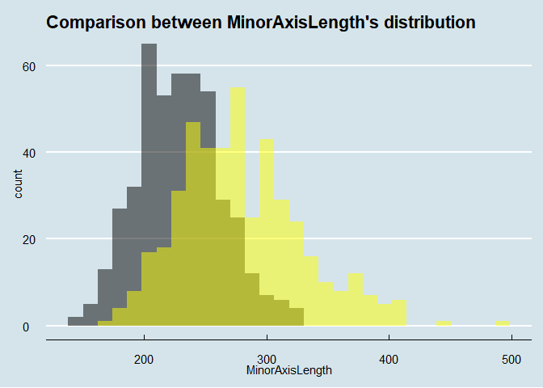

```r
ggplot() +
geom_histogram(data = subset(x=raisins, subset=Class==1),
               aes(x = MinorAxisLength), fill = 'black', alpha = 0.5) +
geom_histogram(data = subset(x=raisins, subset=Class==0),
               aes(x = MinorAxisLength), fill='yellow', alpha = 0.5) +
ggtitle(paste0("Comparison between MinorAxisLength's distribution" ))
```

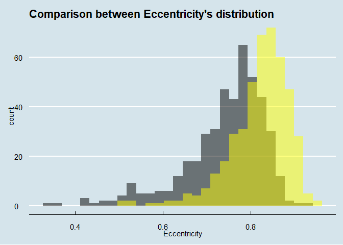

```r
ggplot() +
geom_histogram(data = subset(x=raisins, subset=Class==1),
               aes(x = Eccentricity), fill = 'black', alpha = 0.5) +
geom_histogram(data = subset(x=raisins, subset=Class==0),
               aes(x = Eccentricity), fill='yellow', alpha = 0.5) +
ggtitle(paste0("Comparison between Eccentricity's distribution" ))
```

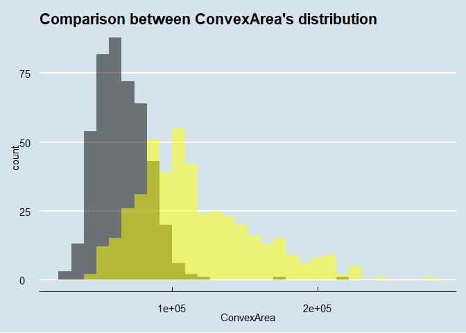

```r
ggplot() +
geom_histogram(data = subset(x=raisins, subset=Class==1),
               aes(x = ConvexArea), fill = 'black', alpha = 0.5) +
geom_histogram(data = subset(x=raisins, subset=Class==0),
               aes(x = ConvexArea), fill='yellow', alpha = 0.5) +
ggtitle(paste0("Comparison between ConvexArea's distribution" ))
```

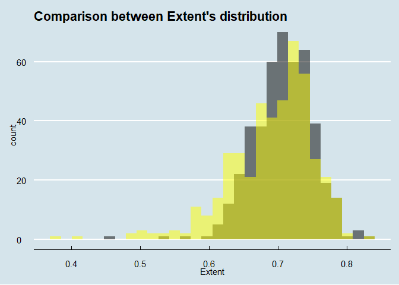

```r
ggplot() +
geom_histogram(data = subset(x=raisins, subset=Class==1),
               aes(x = Extent), fill = 'black', alpha = 0.5) +
geom_histogram(data = subset(x=raisins, subset=Class==0),
               aes(x = Extent), fill='yellow', alpha = 0.5) +
ggtitle(paste0("Comparison between Extent's distribution" ))
```

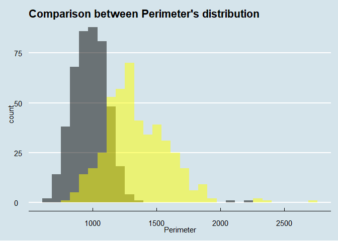

```r
ggplot() +
geom_histogram(data = subset(x=raisins, subset=Class==1),
               aes(x = Perimeter), fill = 'black', alpha = 0.5) +
geom_histogram(data = subset(x=raisins, subset=Class==0),
               aes(x = Perimeter), fill='yellow', alpha = 0.5) +
ggtitle(paste0("Comparison between Perimeter's distribution" ))
```

# Supervised models

## We first use all the dataset

#### We run a basic ols model, which would be a linear probability model

```r
ols <- lm("Class ~ .",data=raisins)
summary(ols)
```

```
##
## Call:
## lm(formula = "Class ~ .", data = raisins)
##
## Residuals:
##      Min       1Q   Median       3Q      Max
## -1.12899 -0.25192  0.01594  0.25715  1.23867
##
## Coefficients:
##                   Estimate Std. Error t value Pr(>|t|)
## (Intercept)      3.568e+00  3.923e-01   9.096  < 2e-16 ***
## Area            -3.869e-05  6.034e-06  -6.412 2.33e-10 ***
## MajorAxisLength  2.189e-03  1.146e-03   1.910  0.05643 .
## MinorAxisLength  2.154e-04  1.483e-03   0.145  0.88456
## Eccentricity    -9.166e-01  2.957e-01  -3.100  0.00199 **
## ConvexArea       4.894e-05  6.059e-06   8.077 2.15e-15 ***
## Extent           8.348e-02  2.772e-01   0.301  0.76337
## Perimeter       -3.837e-03  5.800e-04  -6.616 6.36e-11 ***
## ---
## Signif. codes:  0 '***' 0.001 '**' 0.01 '*' 0.05 '.' 0.1 ' ' 1
##
## Residual standard error: 0.3508 on 892 degrees of freedom
## Multiple R-squared:  0.5123, Adjusted R-squared:  0.5084
## F-statistic: 133.8 on 7 and 892 DF,  p-value: < 2.2e-16
```

#### We check for multicollinearity

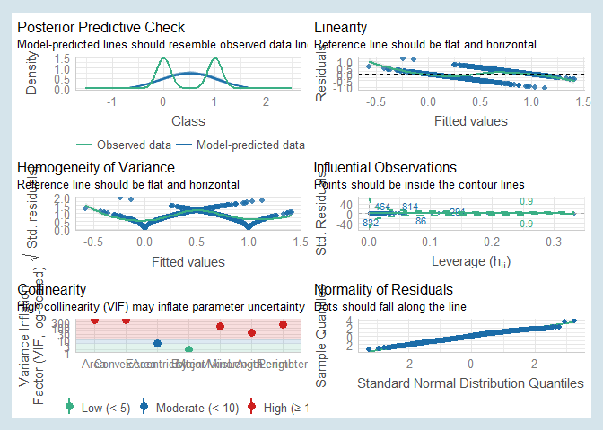

```r
check_model(ols)
```

```r
vif(ols)
```

```
##            Area MajorAxisLength MinorAxisLength    Eccentricity      ConvexArea
##      404.718824      129.152882       40.166637        5.210356      445.947568
##          Extent       Perimeter
##        1.605335      184.252844
```

```r
sqrt(vif(ols)) > 2
```

```
##            Area MajorAxisLength MinorAxisLength    Eccentricity      ConvexArea
##            TRUE            TRUE            TRUE            TRUE            TRUE
##          Extent       Perimeter
##           FALSE            TRUE
```

#### Multicollinearity is extremely high

#### We try to tackle multicollinearity by reducing the variables in the model. We use best subset selection.

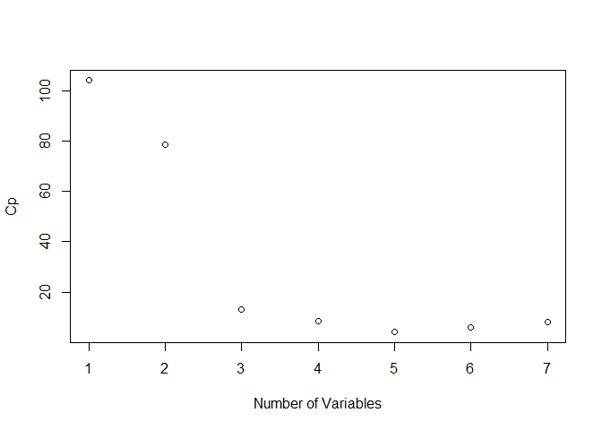

```r
regfit.full=regsubsets(Class ~.,data=raisins, nvmax=7)
reg.summary=summary(regfit.full)
plot(reg.summary$cp,xlab="Number of Variables",ylab="Cp")
```

```r
which.min(reg.summary$cp)
```

```
## [1] 5
```

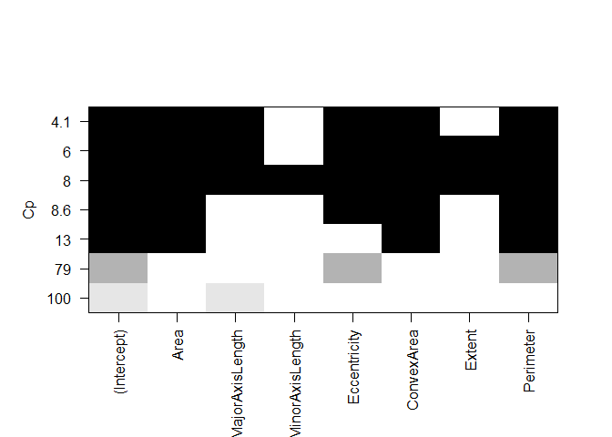

```r
plot(regfit.full,scale="Cp")
```

#### As we can see, the best model appears to be one with 5 variables. We run this improved ols model

```r
ols_imp <- lm("Class ~ Area + MajorAxisLength +
              Eccentricity + ConvexArea + Perimeter",data=raisins)
summary(ols_imp)
```

```
##
## Call:
## lm(formula = "Class ~ Area + MajorAxisLength + \n              Eccentricity + ConvexArea + Perimeter",
##     data = raisins)
##
## Residuals:
##      Min       1Q   Median       3Q      Max
## -1.13065 -0.24783  0.01591  0.25803  1.24484
##
## Coefficients:
##                   Estimate Std. Error t value Pr(>|t|)
## (Intercept)      3.683e+00  2.135e-01  17.252  < 2e-16 ***
## Area            -3.776e-05  4.333e-06  -8.715  < 2e-16 ***
## MajorAxisLength  2.067e-03  8.150e-04   2.536 0.011374 *
## Eccentricity    -9.437e-01  2.628e-01  -3.591 0.000347 ***
## ConvexArea       4.842e-05  5.457e-06   8.875  < 2e-16 ***
## Perimeter       -3.805e-03  4.144e-04  -9.183  < 2e-16 ***
## ---
## Signif. codes:  0 '***' 0.001 '**' 0.01 '*' 0.05 '.' 0.1 ' ' 1
##
## Residual standard error: 0.3504 on 894 degrees of freedom
## Multiple R-squared:  0.5122, Adjusted R-squared:  0.5095
## F-statistic: 187.7 on 5 and 894 DF,  p-value: < 2.2e-16
```

```r
vif(ols_imp) # the VIF is still too high!
```

```
##            Area MajorAxisLength    Eccentricity      ConvexArea       Perimeter
##      209.089582       65.482372        4.124587      362.380343       94.243582
```

#### the VIF is extremely high.

#### Given that most of our variables are highly correlated, we identify three “proper” dimensions over which our data span.

#### Thus, we perform best subset selection specifying that we want at most 3 variables

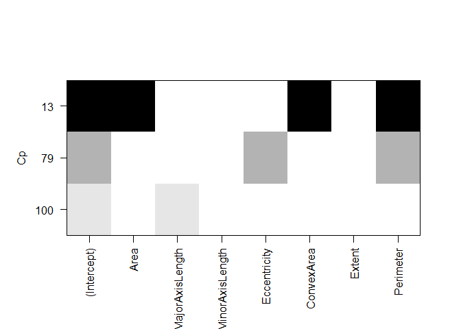

```r
regfit.full=regsubsets(Class ~.,data=raisins, nvmax=3)
reg.summary=summary(regfit.full)
plot(regfit.full,scale="Cp")
```

#### We observe that two variables are very similar. Thus, we opt for the minimal model with two variables.

```r
ols_imp2 <- lm("Class ~ Eccentricity + Perimeter",data=raisins)
summary(ols_imp2)
```

```
##
## Call:
## lm(formula = "Class ~ Eccentricity + Perimeter", data = raisins)
##
## Residuals:
##      Min       1Q   Median       3Q      Max
## -1.03758 -0.30279  0.04866  0.28119  1.80574
##
## Coefficients:
##                Estimate Std. Error t value Pr(>|t|)
## (Intercept)   2.511e+00  1.062e-01  23.634  < 2e-16 ***
## Eccentricity -9.717e-01  1.509e-01  -6.441 1.93e-10 ***
## Perimeter    -1.073e-03  4.977e-05 -21.569  < 2e-16 ***
## ---
## Signif. codes:  0 '***' 0.001 '**' 0.01 '*' 0.05 '.' 0.1 ' ' 1
##
## Residual standard error: 0.3653 on 897 degrees of freedom
## Multiple R-squared:  0.4681, Adjusted R-squared:  0.4669
## F-statistic: 394.8 on 2 and 897 DF,  p-value: < 2.2e-16
```

```r
vif(ols_imp2)
```

```
## Eccentricity    Perimeter
##     1.250884     1.250884
```

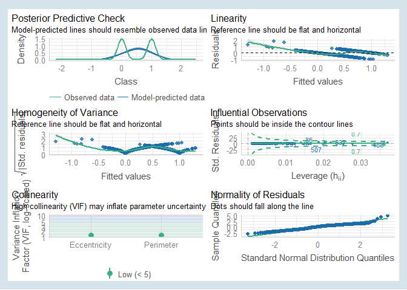

```r
check_model(ols_imp2)
```

#### ols_imp2 is our final model as far as linear regression goes. We now focus on its residuals.

```r
raw_res <- residuals(ols_imp2)
threshold <- 3 * sd(raw_res)  # Define threshold as 3 times the SD
threshold# how are the residuals distributed?
```

```
## [1] 1.094547
```

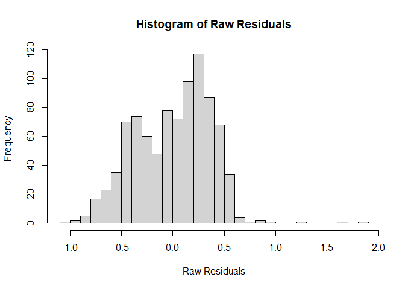

```r
hist(raw_res, breaks = 30, main = "Histogram of Raw Residuals", xlab = "Raw Residuals")
```

#### We also compute Cook’s distance and plot it with the residuals

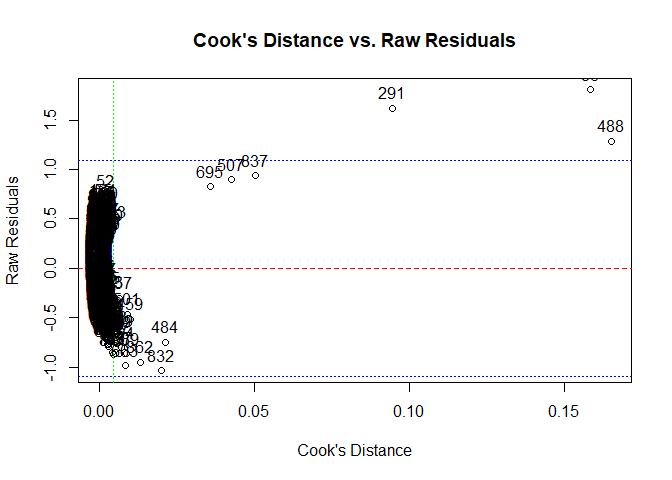

```r
cooks_dist <- cooks.distance(ols_imp2)
cooks_threshold <- 4/897
plot(cooks_dist, raw_res, main = "Cook's Distance vs. Raw Residuals",
     xlab = "Cook's Distance", ylab = "Raw Residuals")
abline(h = 0, lty = 2, col = "red")  # Reference line at y = 0
abline(h = threshold, lty = 3, col = "blue")  # Threshold line for raw residuals (upper)
abline(h = -threshold, lty = 3, col = "blue")  # Threshold line for raw residuals (lower)
abline(v = cooks_threshold, lty = 3, col = "green")
text(cooks_dist, raw_res, labels = 1:length(cooks_dist), pos = 3)
```

#### The most problematic observations appear to be: 695, 507, 837, 291, 86, 488. We should dig deeper into them.

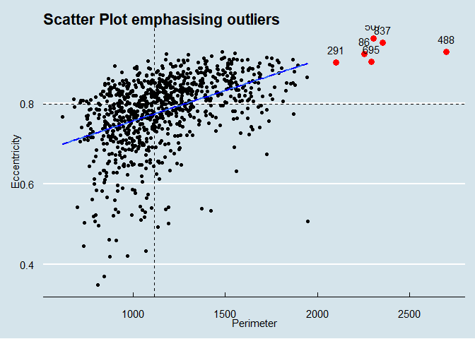

```r
outliers_obs <- c(695, 507, 837, 291, 86, 488)
outliers_df <- raisins[outliers_obs, ]
non_outliers_df <- raisins[-outliers_obs, ]

# Plot without outliers
p <- ggplot(non_outliers_df, aes(x = Perimeter, y = Eccentricity)) +
  geom_point() +
  labs(title = "Scatter Plot emphasising outliers",
       x = "Perimeter",
       y = "Eccentricity")

# Add outliers with distinct color
p <- p +
  geom_point(data = outliers_df, color = "red", size = 3) +
  geom_text(data = outliers_df, aes(label = paste(rownames(outliers_df))), vjust = -1)

# Median values
p <- p +
  geom_vline(aes(xintercept = median(Perimeter)), linetype = "dashed") +
  geom_hline(aes(yintercept = median(Eccentricity)), linetype = "dashed")

# Regression line
p <- p +
  geom_smooth(method = "lm", se = FALSE) +
  geom_smooth(data = non_outliers_df, method = "lm", se = FALSE, linetype = "dashed", color = "blue")

# Display the plot
print(p)
```

#### These observations clearly have a very large “Perimeter”, however they do not appear to be completely out of this world. We can still try to remove them and see how the performance changes. We now plot the accuracy of our model on the whole dataset

```r
#computation of the accuracy on the full dataset
fitvols_fulld = predict(ols_imp2, raisins) # fulld identifies the full dataset
predols_fulld = ifelse(fitvols_fulld < 0.50, 0, 1)
accols_fulld = raisins$Class == predols_fulld
table(accols_fulld)
```

```
## accols_fulld
## FALSE  TRUE
##   124   776
```

```r
accuracy_ols_fulld <- 776/900
accuracy_ols_fulld
```

```
## [1] 0.8622222
```

[output not shown]

#### We run the linear probability model again

```r
ols_imp2_n <- lm("Class ~ Eccentricity + Perimeter",data=raisins_noout) # _n identifies no outliers
summary(ols_imp2_n)
```

```
##
## Call:
## lm(formula = "Class ~ Eccentricity + Perimeter", data = raisins_noout)
##
## Residuals:
##      Min       1Q   Median       3Q      Max
## -1.06624 -0.28222  0.05692  0.27255  0.76195
##
## Coefficients:
##                Estimate Std. Error t value Pr(>|t|)
## (Intercept)   2.6476056  0.1026150  25.801  < 2e-16 ***
## Eccentricity -0.9332612  0.1442159  -6.471  1.6e-10 ***
## Perimeter    -0.0012245  0.0000504 -24.296  < 2e-16 ***
## ---
## Signif. codes:  0 '***' 0.001 '**' 0.01 '*' 0.05 '.' 0.1 ' ' 1
##
## Residual standard error: 0.3489 on 891 degrees of freedom
## Multiple R-squared:  0.5147, Adjusted R-squared:  0.5136
## F-statistic: 472.5 on 2 and 891 DF,  p-value: < 2.2e-16
```

```r
fitvols_fulld_n = predict(ols_imp2_n, raisins_noout) # fulld identifies the full dataset
predols_fulld_n = ifelse(fitvols_fulld_n < 0.50, 0, 1)
accols_fulld_n = raisins_noout$Class == predols_fulld_n
table(accols_fulld_n)
```

```
## accols_fulld_n
## FALSE  TRUE
##   122   772
```

```r
accuracy_ols_fulld_n <- 772/894
accuracy_ols_fulld_n
```

```
## [1] 0.8635347
```

### We now move to logistic regression

```r
logistic_model <-  glm(Class ~ ., data = raisins, family = binomial(link = 'logit'))
tidy(logistic_model)
```

```
## # A tibble: 8 × 5
##   term             estimate std.error statistic      p.value
##   <chr>               <dbl>     <dbl>     <dbl>        <dbl>
## 1 (Intercept)      2.23      7.04         0.317 0.751
## 2 Area            -0.000501  0.000124    -4.03  0.0000566
## 3 MajorAxisLength  0.0446    0.0160       2.79  0.00524
## 4 MinorAxisLength  0.0911    0.0269       3.38  0.000722
## 5 Eccentricity     3.89      4.91         0.792 0.428
## 6 ConvexArea       0.000409  0.000119     3.43  0.000594
## 7 Extent           0.683     2.72         0.251 0.802
## 8 Perimeter       -0.0361    0.00661     -5.46  0.0000000468
```

```r
vif(logistic_model)
```

```
##            Area MajorAxisLength MinorAxisLength    Eccentricity      ConvexArea
##      490.367743       70.630453       83.217726       12.954578      475.455021
##          Extent       Perimeter
##        1.328813       70.195325
```

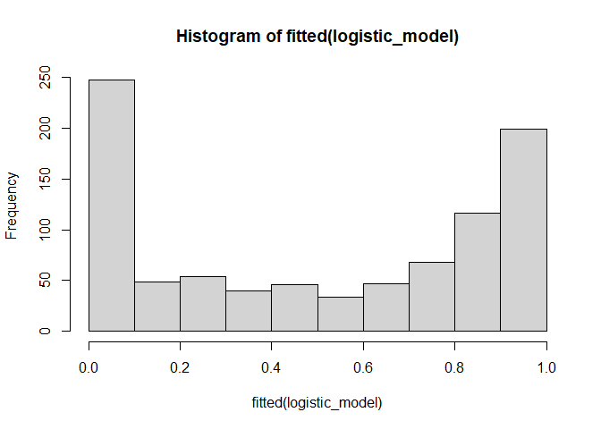

```r
hist(fitted(logistic_model))
```

```r
bestglm(raisins, family = gaussian, IC = "BIC")
```

```
## BIC
## BICq equivalent for q in (5.38544187023149e-09, 0.532772479819852)
## Best Model:
##                  Estimate   Std. Error    t value     Pr(>|t|)
## (Intercept)  3.228091e+00 1.445365e-01  22.334086 3.460498e-88
## Area        -3.835214e-05 4.104717e-06  -9.343431 7.200693e-20
## ConvexArea   5.187278e-05 5.028354e-06  10.316057 1.180887e-23
## Perimeter   -3.508593e-03 2.454475e-04 -14.294674 6.599333e-42
```

```r
imp_logistic_model <- glm(Class ~ Area + ConvexArea + Perimeter,
                    data = raisins,
                    family = binomial(link = 'logit'))
vif(imp_logistic_model)
```

```
##       Area ConvexArea  Perimeter
##  422.14309  554.65662   22.25865
```

#### These still appears to have multicollinearity issues.

#### As before, we use our intuition to build a minimal logistic model

#### We actually build two of them:

```r
minimal1_logistic_model <-  glm(Class ~ Extent + Eccentricity, data = raisins, family = binomial(link = 'logit'))
vif(minimal1_logistic_model)
```

```
##       Extent Eccentricity
##     1.116328     1.116328
```

```r
minimal2_logistic_model <-  glm(Class ~ Eccentricity + Perimeter, data = raisins,family = binomial(link = 'logit'))
vif(minimal2_logistic_model)
```

```
## Eccentricity    Perimeter
##     1.012988     1.012988
```

#### We now create a table with the accuracies of all our models

```r
accuracies <- data.frame(Model = character(),
                         Accuracy = numeric())

models <- list(logistic = logistic_model,
               imp_logistic = imp_logistic_model,
               minimal_logit_extent = minimal1_logistic_model,
               minimal_logit_perimeter = minimal2_logistic_model,
               lpm = ols_imp2)

for (model_name in names(models)) {
  model <- models[[model_name]]

  # Predict the outcome probabilities using the logistic regression model
  pred_pr <- predict(model, raisins, type = "response")
  # Convert the predicted probabilities to binary predictions (0 or 1)
  pred_val <- ifelse(pred_pr > 0.5, 1, 0)
  # Compare the predicted values with the actual outcome variable
  actual_values <- raisins$Class
  # Compute the number of correctly predicted values
  correctly_pred <- sum(pred_val == actual_values)
  # Compute the percentage of correctly predicted values
  accuracy <- correctly_pred / length(actual_values) * 100
  # Append the accuracy to the "accuracies" data frame
  accuracies <- rbind(accuracies, data.frame(Model = model_name, Accuracy = accuracy))
}

accuracies
```

```
##                     Model Accuracy
## 1                logistic 85.77778
## 2            imp_logistic 85.33333
## 3    minimal_logit_extent 70.77778
## 4 minimal_logit_perimeter 86.44444
## 5                     lpm 86.22222
```

#### Since the minimal logisitc model with the perimeter is the best one, we compute diagnostics on it.

# Diagnostics with DHARMa

[output not shown]

```
## # Comparison of Model Performance Indices
##
## Name                    | Model | AIC (weights) | AICc (weights) | BIC (weights) |  RMSE | Sigma |    R2 | R2 (adj.) | Tjur's R2 | Log_loss | Score_log | Score_spherical |   PCP
## ---------------------------------------------------------------------------------------------------------------------------------------------------------------------------------
## ols_imp2                |    lm | 746.2 (<.001) |  746.2 (<.001) | 765.4 (<.001) | 0.365 | 0.365 | 0.468 |     0.467 |           |          |           |                 |
## minimal2_logistic_model |   glm | 636.2 (>.999) |  636.3 (>.999) | 650.6 (>.999) | 0.320 | 0.838 |       |           |     0.574 |    0.350 |      -Inf |           0.008 | 0.787
```

```r
# Create a simulated residuals object
simulated_residuals <- simulateResiduals(minimal2_logistic_model, n = 100)
# Plot standardized residuals using DHARMa's built-in diagnostic plots
plot(simulated_residuals)
```

```r
accuracies
```

```
##                     Model Accuracy
## 1                logistic 85.77778
## 2            imp_logistic 85.33333
## 3    minimal_logit_extent 70.77778
## 4 minimal_logit_perimeter 86.44444
## 5                     lpm 86.22222
```

## We now performe some actual statistical learning

#### We split our data in train and test set

```r
library(caret)

set.seed(42)
training_index = createDataPartition(raisins$Class, p=0.7, list = FALSE) # index of the train set examples
train = raisins[training_index,]
test = raisins[-training_index,]
```

#### MSE Function

(Aim: to evaluate the performance of predictive models)

```r
mse = function(predictions,data,y){
  residuals = (predictions - (data[c(y)]))
  mse = (1/nrow(data))*sum((residuals^2))
  return(mse)
}
```

#### Accuracy function

```r
# Casual Deep Learning accuracy function
CDP_accuracy <- function(test_predictions_vector, test_set){
        model_classes = ifelse(test_predictions_vector >= 0.5, 1,0)
        modelCM<-table(model_classes,test_set$Class)
        modelCM
        model_right_guesses = modelCM[1] + modelCM[4]
        model_accuracy = model_right_guesses/length(model_classes)
        return(model_accuracy)
        }
```

## MODELS

### 1. OLS

```r
# Fit the linear regression model
ols = lm("Class ~ Perimeter + Eccentricity",data=train)
# Summary of the model
print(summary(ols))
```

```
##
## Call:
## lm(formula = "Class ~ Perimeter + Eccentricity", data = train)
##
## Residuals:
##      Min       1Q   Median       3Q      Max
## -0.99737 -0.29624  0.05971  0.27956  1.33647
##
## Coefficients:
##                Estimate Std. Error t value Pr(>|t|)
## (Intercept)   2.491e+00  1.256e-01  19.836  < 2e-16 ***
## Perimeter    -1.115e-03  5.709e-05 -19.525  < 2e-16 ***
## Eccentricity -8.843e-01  1.762e-01  -5.019 6.79e-07 ***
## ---
## Signif. codes:  0 '***' 0.001 '**' 0.01 '*' 0.05 '.' 0.1 ' ' 1
##
## Residual standard error: 0.3584 on 627 degrees of freedom
## Multiple R-squared:  0.4887, Adjusted R-squared:  0.4871
## F-statistic: 299.7 on 2 and 627 DF,  p-value: < 2.2e-16
```

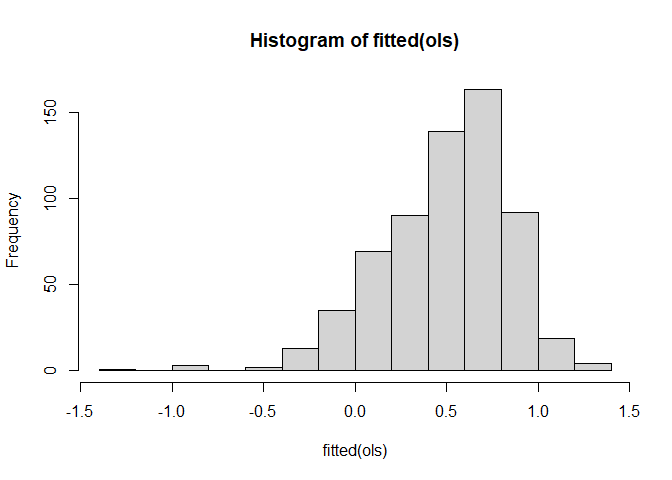

```r
# Predictions on the test data
ols_test_predictions = predict.lm(ols,newdata = test)
# Histogram of the fitted values
hist(fitted(ols))
```

```r
# Calculate MSE for the training data
mse_train<-mse(fitted(ols), train, "Class") #training error
mse_train
```

```
## [1] 0.1278151
```

```r
# Calculate MSE for the test data
mse_test<-mse(ols_test_predictions,test,"Class") #test error
# Calculate accuracy
CDP_accuracy(ols_test_predictions, test)
```

```
## [1] 0.8555556
```

```r
mse_test # it was 0.1346953 before changing variables # it's 0.145 after reducing the model
```

```
## [1] 0.1453523
```

### 2. ROBUST OLS

```r
library(sandwich)
library(lmtest)
library(MASS)

# Fit the robust linear regression model
ols_robust = rlm(Class ~ ., data = train, se_type = "HC2")
# Summary of the robust model
summary(ols_robust)
```

```
##
## Call: rlm(formula = Class ~ ., data = train, se_type = "HC2")
## Residuals:
##      Min       1Q   Median       3Q      Max
## -1.19202 -0.24001  0.01411  0.23545  0.70461
##
## Coefficients:
##                 Value   Std. Error t value
## (Intercept)      3.8754  0.4719     8.2122
## Area             0.0000  0.0000    -5.1532
## MajorAxisLength  0.0022  0.0014     1.6373
## MinorAxisLength -0.0002  0.0018    -0.1314
## Eccentricity    -0.8842  0.3523    -2.5096
## ConvexArea       0.0000  0.0000     6.9109
## Extent           0.0672  0.3316     0.2028
## Perimeter       -0.0042  0.0007    -5.9900
##
## Residual standard error: 0.3521 on 622 degrees of freedom
```

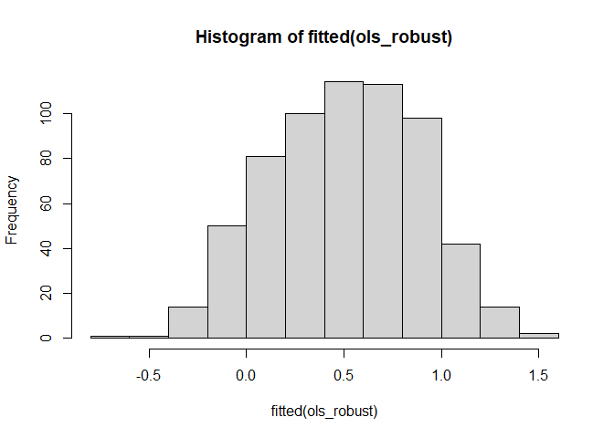

```r
# Predictions on the test data
ols_robust_test_predictions = predict(ols_robust, newdata = test)
# Histogram of the fitted values
hist(fitted(ols_robust))
```

```r
# Calculate MSE for the training data
mse(fitted(ols_robust), train, "Class") #training error
```

```
## [1] 0.1175795
```

```r
# Calculate MSE for the test data
mse(ols_robust_test_predictions, test, "Class") #test error
```

```
## [1] 0.1356805
```

```r
# Calculate accuracy
CDP_accuracy(ols_robust_test_predictions, test)
```

```
## [1] 0.8481481
```

### 3. LOGISTIC

```r
library(broom)

# 3. Logistic before diagnostic
logistic = glm(Class ~ ., data = train, family = binomial(link = 'logit'))
tidy(logistic)
```

```
## # A tibble: 8 × 5
##   term              estimate std.error statistic p.value
##   <chr>                <dbl>     <dbl>     <dbl>   <dbl>
## 1 (Intercept)     -13.3       8.67       -1.54   0.124
## 2 Area              0.000473  0.000228    2.08   0.0377
## 3 MajorAxisLength   0.0184    0.0222      0.831  0.406
## 4 MinorAxisLength   0.113     0.0355      3.18   0.00147
## 5 Eccentricity     12.1       5.07        2.40   0.0166
## 6 ConvexArea       -0.000706  0.000226   -3.12   0.00179
## 7 Extent           -0.135     3.55       -0.0381 0.970
## 8 Perimeter        -0.0100    0.00926    -1.09   0.278
```

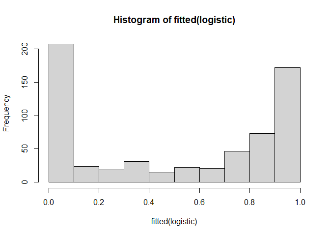

```r
hist(fitted(logistic))
```

```r
#logistic by hand
logistic_test_predictions = predict(logistic, newdata = test)
mse(fitted(logistic), train, "Class") # 0.09080575 before <- 0.09835077 after
```

```
## [1] 0.09080575
```

```r
mse(logistic_test_predictions, test, "Class")
```

```
## [1] 37.4428
```

```r
CDP_accuracy(logistic_test_predictions, test)
```

```
## [1] 0.8740741
```

```r
# 3. Logistic after diagnostic
logistic_ad = glm(Class ~ Perimeter + Eccentricity, data = train, family = binomial(link = 'logit'))
tidy(logistic_ad)
```

```
## # A tibble: 3 × 5
##   term         estimate std.error statistic  p.value
##   <chr>           <dbl>     <dbl>     <dbl>    <dbl>
## 1 (Intercept)   19.3      1.78        10.8  3.03e-27
## 2 Perimeter     -0.0124   0.00109    -11.4  5.86e-30
## 3 Eccentricity  -6.79     1.81        -3.76 1.72e- 4
```

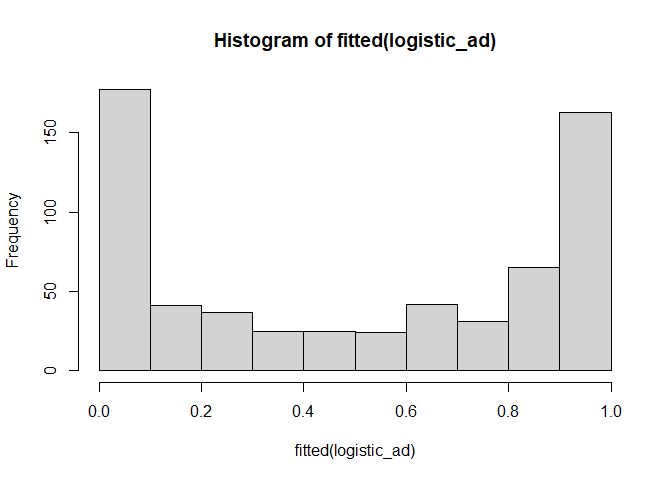

```r
hist(fitted(logistic_ad))
```

```r
#logistic by hand
logistic_ad_test_predictions = predict(logistic_ad, newdata = test)
mse(fitted(logistic_ad), train, "Class") # 0.09080575 before <- 0.09835077 after
```

```
## [1] 0.09835077
```

```r
mse(logistic_ad_test_predictions, test, "Class")
```

```
## [1] 12.18564
```

```r
CDP_accuracy(logistic_ad_test_predictions, test)
```

```
## [1] 0.8481481
```